# SWIRE EDA - Joonas

Joonas Tahvanainen

2025-02-20

```r
library(tidyverse)
library(dplyr)
library(tidyr)
library(skimr)
library(janitor)
library(lubridate)

address_mapping <- read_csv("customer_address_and_zip_mapping.csv")
customer_profile <- read_csv("customer_profile.csv")
delivery_costs <- read_csv("delivery_cost_data.csv")
transactions <- read_csv("transactional_data.csv")
```

# Data preparation

## Address data cleaning (address mapping)

I’m not sure if the address data will be used for anything, but to make it usable, I’ll modify it a little bit just in case:

```r
# checking the current formatting
head(address_mapping, n=3)
```

```
## # A tibble: 3 × 2
##     zip `full address`
##   <dbl> <chr>
## 1 71018 71018,Cotton Valley,Louisiana,LA,Webster,119,32.819,-93.4259
## 2 71021 71021,Cullen,Louisiana,LA,Webster,119,32.9721,-93.4492
## 3 71023 71023,Doyline,Louisiana,LA,Webster,119,32.49,-93.3996
```

The full address is not very clean from data standpoint so I’ll just separate the different address items.

```r
address_mapping <- address_mapping %>%
  rename(full_address = `full address`, zip_code = zip) %>%
  separate(full_address, into = c("zip_full", "city", "state", "state_short", "county", "unknown", "latitude", "longitude"), sep = ",", convert = TRUE) %>%
  select(-unknown, -zip_full)

head(address_mapping)
```

```
## # A tibble: 6 × 7
##   zip_code city          state     state_short county  latitude longitude
##      <dbl> <chr>         <chr>     <chr>       <chr>      <dbl>     <dbl>
## 1    71018 Cotton Valley Louisiana LA          Webster     32.8     -93.4
## 2    71021 Cullen        Louisiana LA          Webster     33.0     -93.4
## 3    71023 Doyline       Louisiana LA          Webster     32.5     -93.4
## 4    71024 Dubberly      Louisiana LA          Webster     32.5     -93.2
## 5    71039 Heflin        Louisiana LA          Webster     32.4     -93.3
## 6    71055 Minden        Louisiana LA          Webster     32.6     -93.3
```

## Customer profile data cleaning

Taking a quick glance at the data first:

```r
head(customer_profile)
```

```
## # A tibble: 6 × 11
##   CUSTOMER_NUMBER PRIMARY_GROUP_NUMBER FREQUENT_ORDER_TYPE FIRST_DELIVERY_DATE
##             <dbl>                <dbl> <chr>               <chr>
## 1       501556470                  376 MYCOKE LEGACY       1/2/2024
## 2       501363456                   NA SALES REP           4/14/2022
## 3       600075150                 2158 SALES REP           3/4/2016
## 4       500823056                 2183 OTHER               2/6/2019
## 5       600082383                 1892 SALES REP           3/4/2016
## 6       600079420                   NA SALES REP           3/10/2016
## # ℹ 7 more variables: ON_BOARDING_DATE <chr>, COLD_DRINK_CHANNEL <chr>,
## #   TRADE_CHANNEL <chr>, SUB_TRADE_CHANNEL <chr>, LOCAL_MARKET_PARTNER <lgl>,
## #   CO2_CUSTOMER <lgl>, ZIP_CODE <dbl>
```

I’m not a fan of all caps column names, so I’ll clean those real quick. Also, we can see above that the date columns are in character format. No need to change that now. Just taking a mental note of it.

Also, at this point I’ll join the address mapping data, since it will give us the cities and the states for the customer profile.

```r
customer_profile <- customer_profile %>% clean_names()
customer_profile <- customer_profile %>%
  left_join(address_mapping, by = "zip_code")
head(customer_profile)
```

```
## # A tibble: 6 × 17
##   customer_number primary_group_number frequent_order_type first_delivery_date
##             <dbl>                <dbl> <chr>               <chr>
## 1       501556470                  376 MYCOKE LEGACY       1/2/2024
## 2       501363456                   NA SALES REP           4/14/2022
## 3       600075150                 2158 SALES REP           3/4/2016
## 4       500823056                 2183 OTHER               2/6/2019
## 5       600082383                 1892 SALES REP           3/4/2016
## 6       600079420                   NA SALES REP           3/10/2016
## # ℹ 13 more variables: on_boarding_date <chr>, cold_drink_channel <chr>,
## #   trade_channel <chr>, sub_trade_channel <chr>, local_market_partner <lgl>,
## #   co2_customer <lgl>, zip_code <dbl>, city <chr>, state <chr>,
## #   state_short <chr>, county <chr>, latitude <dbl>, longitude <dbl>
```

Next, quick skim on the dataframe should give us most of what we need for EDA on this dataframe

```r
skim(customer_profile)
```

Data summary

| Name | customer_profile |
| --- | --- |
| Number of rows | 30478 |
| Number of columns | 17 |
| _______________________ |  |
| Column type frequency: |  |
| character | 10 |
| logical | 2 |
| numeric | 5 |
| ________________________ |  |
| Group variables | None |

**Variable type: character**

| skim_variable | n_missing | complete_rate | min | max | empty | n_unique | whitespace |
| --- | --- | --- | --- | --- | --- | --- | --- |
| frequent_order_type | 0 | 1 | 3 | 13 | 0 | 6 | 0 |
| first_delivery_date | 0 | 1 | 8 | 10 | 0 | 2401 | 0 |
| on_boarding_date | 0 | 1 | 8 | 10 | 0 | 6487 | 0 |
| cold_drink_channel | 0 | 1 | 5 | 13 | 0 | 9 | 0 |
| trade_channel | 0 | 1 | 6 | 28 | 0 | 26 | 0 |
| sub_trade_channel | 0 | 1 | 4 | 27 | 0 | 48 | 0 |
| city | 0 | 1 | 3 | 23 | 0 | 1355 | 0 |
| state | 0 | 1 | 6 | 13 | 0 | 5 | 0 |
| state_short | 0 | 1 | 2 | 2 | 0 | 5 | 0 |
| county | 0 | 1 | 4 | 16 | 0 | 134 | 0 |

**Variable type: logical**

| skim_variable | n_missing | complete_rate | mean | count |
| --- | --- | --- | --- | --- |
| local_market_partner | 0 | 1 | 0.90 | TRU: 27355, FAL: 3123 |
| co2_customer | 0 | 1 | 0.39 | FAL: 18496, TRU: 11982 |

**Variable type: numeric**

| skim_variable | n_missing | complete_rate | mean | sd | p0 | p25 | p50 | p75 | p100 | hist |
| --- | --- | --- | --- | --- | --- | --- | --- | --- | --- | --- |
| customer_number | 0 | 1.0 | 538301800.92 | 47950644.47 | 500245678.00 | 501164305.75 | 501573994.50 | 600075795.00 | 600975408.00 | ▇▁▁▁▅ |
| primary_group_number | 18196 | 0.4 | 2779.85 | 2608.64 | 4.00 | 444.00 | 1892.00 | 4488.00 | 9999.00 | ▇▃▂▁▁ |
| zip_code | 0 | 1.0 | 30252.25 | 25953.08 | 1001.00 | 2155.00 | 21771.00 | 42762.00 | 71483.00 | ▇▃▅▁▆ |
| latitude | 0 | 1.0 | 39.72 | 2.19 | 30.36 | 37.97 | 39.34 | 42.15 | 42.86 | ▁▁▅▇▇ |
| longitude | 0 | 1.0 | -81.99 | 10.37 | -102.00 | -89.19 | -77.38 | -71.87 | -69.96 | ▅▁▅▃▇ |

**SKIM Main takeaways**:

- Only primary group number has missing values. Only 40.3% have them. Likely due to customers not belonging to a group.
- 6 different frequent order types
- 9 different cold drink channels
- 89.75& of customers are local market partners
- 39.31% of customers are CO2 customers

Next up:

- Make sure no customers are duplicated
- Assign a number to all NA group numbers (for data quality)
- Summarize data by order types
- Summarize data by cold drink channels

```r
# check for duplicates
customer_profile %>%
  group_by(customer_number) %>%
  filter(n() > 1)
```

```
## # A tibble: 0 × 17
## # Groups:   customer_number [0]
## # ℹ 17 variables: customer_number <dbl>, primary_group_number <dbl>,
## #   frequent_order_type <chr>, first_delivery_date <chr>,
## #   on_boarding_date <chr>, cold_drink_channel <chr>, trade_channel <chr>,
## #   sub_trade_channel <chr>, local_market_partner <lgl>, co2_customer <lgl>,
## #   zip_code <dbl>, city <chr>, state <chr>, state_short <chr>, county <chr>,
## #   latitude <dbl>, longitude <dbl>
```

```r
#check to make sure number 1 is not taken
customer_profile %>%
  filter(primary_group_number == 1)
```

```
## # A tibble: 0 × 17
## # ℹ 17 variables: customer_number <dbl>, primary_group_number <dbl>,
## #   frequent_order_type <chr>, first_delivery_date <chr>,
## #   on_boarding_date <chr>, cold_drink_channel <chr>, trade_channel <chr>,
## #   sub_trade_channel <chr>, local_market_partner <lgl>, co2_customer <lgl>,
## #   zip_code <dbl>, city <chr>, state <chr>, state_short <chr>, county <chr>,
## #   latitude <dbl>, longitude <dbl>
```

```r
customer_profile <- customer_profile %>%
  mutate(primary_group_number = ifelse(is.na(primary_group_number), 1, primary_group_number))

# make sure that there's no more NA's
customer_profile %>%
  filter(is.na(primary_group_number))
```

```
## # A tibble: 0 × 17
## # ℹ 17 variables: customer_number <dbl>, primary_group_number <dbl>,
## #   frequent_order_type <chr>, first_delivery_date <chr>,
## #   on_boarding_date <chr>, cold_drink_channel <chr>, trade_channel <chr>,
## #   sub_trade_channel <chr>, local_market_partner <lgl>, co2_customer <lgl>,
## #   zip_code <dbl>, city <chr>, state <chr>, state_short <chr>, county <chr>,
## #   latitude <dbl>, longitude <dbl>
```

Next, checking counts and percentages of frequent order types.

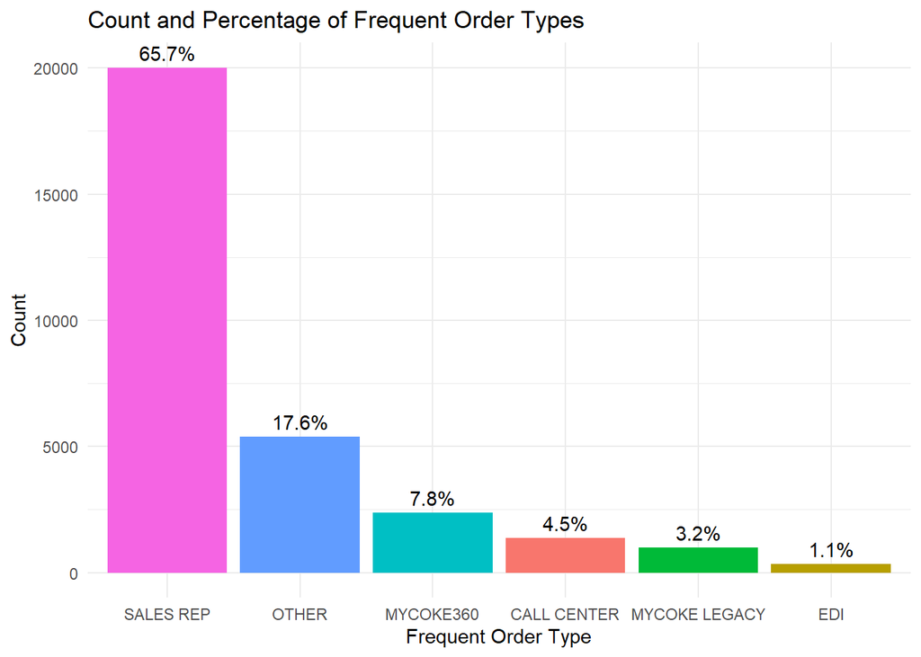

Looks like most customers (65.7%) have their most frequent order go through a sales rep.

I’ll do the same chart with the cold drink channels to look for patterns.

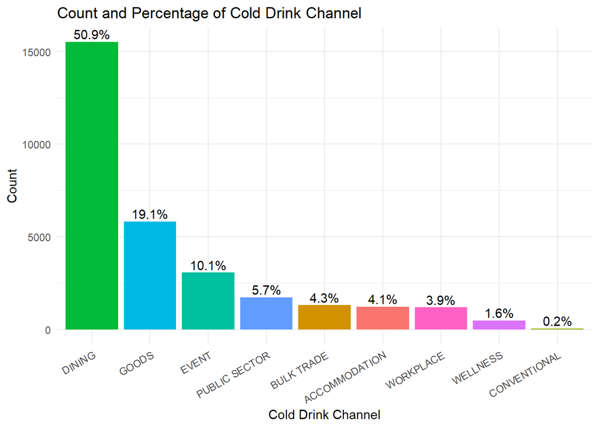

Looks like over 80% of the customers are either in the dining, goods, or event cold drink channels.

## Transactional data cleanup and aggregating

```r
skim(transactions)
```

Data summary

| Name | transactions |
| --- | --- |
| Number of rows | 1045540 |
| Number of columns | 11 |
| _______________________ |  |
| Column type frequency: |  |
| character | 2 |
| numeric | 9 |
| ________________________ |  |
| Group variables | None |

**Variable type: character**

| skim_variable | n_missing | complete_rate | min | max | empty | n_unique | whitespace |
| --- | --- | --- | --- | --- | --- | --- | --- |
| TRANSACTION_DATE | 0 | 1 | 8 | 10 | 0 | 723 | 0 |
| ORDER_TYPE | 0 | 1 | 3 | 13 | 0 | 7 | 0 |

**Variable type: numeric**

| skim_variable | n_missing | complete_rate | mean | sd | p0 | p25 | p50 | p75 | p100 | hist |
| --- | --- | --- | --- | --- | --- | --- | --- | --- | --- | --- |
| WEEK | 0 | 1 | 26.23 | 14.52 | 1.0 | 14 | 26 | 38.00 | 52.00 | ▇▇▇▇▇ |
| YEAR | 0 | 1 | 2023.50 | 0.50 | 2023.0 | 2023 | 2023 | 2024.00 | 2024.00 | ▇▁▁▁▇ |
| CUSTOMER_NUMBER | 0 | 1 | 546643776.32 | 49426585.56 | 500245678.0 | 501091920 | 501548213 | 600080939.00 | 600975408.00 | ▇▁▁▁▇ |
| ORDERED_CASES | 0 | 1 | 26.85 | 126.76 | 0.0 | 0 | 7 | 18.50 | 8479.89 | ▇▁▁▁▁ |
| LOADED_CASES | 0 | 1 | 25.92 | 122.79 | 0.0 | 0 | 7 | 18.00 | 8171.56 | ▇▁▁▁▁ |
| DELIVERED_CASES | 0 | 1 | 25.13 | 121.52 | -3132.0 | 0 | 6 | 17.33 | 8069.48 | ▁▇▁▁▁ |
| ORDERED_GALLONS | 0 | 1 | 9.87 | 26.47 | 0.0 | 0 | 0 | 12.50 | 2562.50 | ▇▁▁▁▁ |
| LOADED_GALLONS | 0 | 1 | 9.60 | 25.65 | 0.0 | 0 | 0 | 12.50 | 2562.50 | ▇▁▁▁▁ |
| DELIVERED_GALLONS | 0 | 1 | 9.21 | 25.18 | -1792.5 | 0 | 0 | 12.50 | 2292.50 | ▁▁▇▁▁ |

**Transactions skim takeaways**

- No missing values
- Two years of data (2023 + 2024)
- Delivered_cases and delivered_gallons have negative values

To do next:

- Clean up column names again
- Investigate negative values
- Basic EDA on transactions

Clean up column names:

```r
transactions <- transactions %>% clean_names()
head(transactions)
```

```
## # A tibble: 6 × 11
##   transaction_date  week  year customer_number order_type    ordered_cases
##   <chr>            <dbl> <dbl>           <dbl> <chr>                 <dbl>
## 1 1/5/2023             1  2023       501202893 MYCOKE LEGACY           1
## 2 1/6/2023             1  2023       500264574 MYCOKE LEGACY          12.5
## 3 1/9/2023             2  2023       501174701 MYCOKE LEGACY           2
## 4 1/11/2023            2  2023       600586532 SALES REP              18
## 5 1/17/2023            3  2023       501014325 SALES REP              29
## 6 1/23/2023            4  2023       600567384 CALL CENTER             1.5
## # ℹ 5 more variables: loaded_cases <dbl>, delivered_cases <dbl>,
## #   ordered_gallons <dbl>, loaded_gallons <dbl>, delivered_gallons <dbl>
```

```r
# pulling a few negative delivered_cases
transactions %>%
  select(transaction_date, order_type, customer_number, delivered_cases, delivered_gallons) %>%
  filter(delivered_cases < 0 & delivered_gallons < 0) %>%
  arrange(customer_number) %>% head(25)
```

```
## # A tibble: 25 × 5
##    transaction_date order_type customer_number delivered_cases delivered_gallons
##    <chr>            <chr>                <dbl>           <dbl>             <dbl>
##  1 3/9/2023         null             500301624          -1                 -2.5
##  2 7/13/2023        CALL CENT…       500311931         -24               -115
##  3 5/2/2024         null             500339775         -13                -30
##  4 10/31/2023       null             500344992        -192                -32.5
##  5 11/21/2024       null             500376318          -6.5              -20
##  6 11/20/2024       null             500401833         -98                -30
##  7 7/12/2024        null             500405064          -0.508             -4.00
##  8 3/31/2023        null             500411198         -49                -62.5
##  9 4/2/2024         null             500411198         -33                -70
## 10 4/3/2023         null             500411198        -124               -108.
## # ℹ 15 more rows
```

```r
# pulling all orders for a few customers that had negative delivered_cases to look for trends
transactions %>%
  filter(customer_number == 500344992 | customer_number == 500411198) %>%
  mutate(transaction_date = as.Date(transaction_date, format = "%m/%d/%Y")) %>%
  arrange(customer_number, transaction_date)
```

```
## # A tibble: 67 × 11
##    transaction_date  week  year customer_number order_type ordered_cases
##    <date>           <dbl> <dbl>           <dbl> <chr>              <dbl>
##  1 2023-08-10          32  2023       500344992 SALES REP             84
##  2 2023-09-28          39  2023       500344992 OTHER                400
##  3 2023-10-05          40  2023       500344992 null                   0
##  4 2023-10-09          41  2023       500344992 null                   0
##  5 2023-10-10          41  2023       500344992 null                   0
##  6 2023-10-12          41  2023       500344992 null                   0
##  7 2023-10-13          41  2023       500344992 null                   0
##  8 2023-10-31          44  2023       500344992 null                   0
##  9 2024-09-24          39  2024       500344992 SALES REP           1176
## 10 2024-09-26          39  2024       500344992 SALES REP              0
## # ℹ 57 more rows
## # ℹ 5 more variables: loaded_cases <dbl>, delivered_cases <dbl>,
## #   ordered_gallons <dbl>, loaded_gallons <dbl>, delivered_gallons <dbl>
```

```r
# checking the total number of rows where delivered_cases or delivered_gallons were negative
transactions %>%
  filter(delivered_cases < 0 | delivered_gallons < 0) %>%
  nrow()
```

```
## [1] 4221
```

**Takeaways:**

- I’m not seeing any clear reason for the negative delivery values. They could be returns or something else
- Also, looking at this output, looks like where order_type is null, ordered_cases are mostly 0. Let’s see if that’s true:

```r
transactions %>%
  filter(order_type == "null") %>%
  select(ordered_cases) %>%
  summarise(
    mean_cases = mean(ordered_cases),
    median_cases = median(ordered_cases),
    min_cases = min(ordered_cases),
    max_cases = max(ordered_cases)
)
```

```
## # A tibble: 1 × 4
##   mean_cases median_cases min_cases max_cases
##        <dbl>        <dbl>     <dbl>     <dbl>
## 1       25.8            0         0      2652
```

- Looks like null order_type doesn’t mean that ordered_cases were 0.
- Based on what I’ve found so far regarding the zero values and null order types, I can’t really make a decision how to handle those yet

```r
# checking the number of rows where order_type is null
transactions %>% filter(order_type == "null") %>%
  nrow()
```

```
## [1] 11131
```

**Notes from stakeholders:**

Based on thee sponsor’s notes, the transactional data is already been aggregated to daily totals by the customer. Sometimes an order doesn’t get filled on the same date, which could be causing the discrepancies between ordered vs. loaded vs. delivered.

Also, it’s good to note that cases equal to gallons, so they can be combined in calculations.

With that being said, I’ll start by adding some calculated columns for total gallons ordered, loaded, and delivered. That might eventually be helpful with the yearly 400 gallon threshold.

```r
transactions <- transactions %>%
  mutate(total_gallons_ordered = ordered_cases + ordered_gallons,
         total_gallons_loaded = loaded_cases + loaded_gallons,
         total_gallons_delivered = delivered_cases + delivered_gallons)

transactions %>% head()
```

```
## # A tibble: 6 × 14
##   transaction_date  week  year customer_number order_type    ordered_cases
##   <chr>            <dbl> <dbl>           <dbl> <chr>                 <dbl>
## 1 1/5/2023             1  2023       501202893 MYCOKE LEGACY           1
## 2 1/6/2023             1  2023       500264574 MYCOKE LEGACY          12.5
## 3 1/9/2023             2  2023       501174701 MYCOKE LEGACY           2
## 4 1/11/2023            2  2023       600586532 SALES REP              18
## 5 1/17/2023            3  2023       501014325 SALES REP              29
## 6 1/23/2023            4  2023       600567384 CALL CENTER             1.5
## # ℹ 8 more variables: loaded_cases <dbl>, delivered_cases <dbl>,
## #   ordered_gallons <dbl>, loaded_gallons <dbl>, delivered_gallons <dbl>,
## #   total_gallons_ordered <dbl>, total_gallons_loaded <dbl>,
## #   total_gallons_delivered <dbl>
```

## Joining and aggregating datasets

So far I’ve been mostly cleaning up the datasets and getting familiar with the data, granularity, and formatting. In the next steps, I’m planning on doing more analysis from the actual perspective of the assignment. This inluceds answering questions like:

- Finding out how much customers are generally ordering yearly (and possibly within other timeframes). As I recall, one of the objectives of the analysis is to find out if the 400 gallon yearly mark is the most optimal for Swire.
- Aggregating data and thinking about what format the data should be in, and whether it’s possible to (in the next steps) predict the high growth customers.

Before joining datasets, I want to see how many, if all of the customers from the customer_profile dataframe have a matching customer_number in the transactions data, and vise versa.

```r
na_transactions <- transactions %>%
  anti_join(customer_profile, by = "customer_number") %>%
  distinct(customer_number) %>% nrow()

na_customer_profile <- customer_profile %>%
  anti_join(transactions, by = "customer_number") %>%
  distinct(customer_number) %>% nrow()

cat("There are", na_transactions, "customer numbers in the transactions dataframe that don't have a match in the customer_profile dataframe.\n")
```

```
## There are 0 customer numbers in the transactions dataframe that don't have a match in the customer_profile dataframe.
```

```r
cat("There are", na_customer_profile, "customer numbers in the customer_profile dataframe that don't have a match in the transactions dataframe.\n")
```

```
## There are 156 customer numbers in the customer_profile dataframe that don't have a match in the transactions dataframe.
```

Looks like in total there are 156 customers in the customer_profile that don’t have any transactions in the transaction data frame.

```r
customer_profile %>%
  anti_join(transactions, by = "customer_number") %>% head(25)
```

```
## # A tibble: 25 × 17
##    customer_number primary_group_number frequent_order_type first_delivery_date
##              <dbl>                <dbl> <chr>               <chr>
##  1       500953257                    1 MYCOKE LEGACY       7/26/2019
##  2       600250380                    1 SALES REP           8/30/2016
##  3       501230653                    1 MYCOKE LEGACY       7/9/2021
##  4       600280552                    1 SALES REP           9/7/2017
##  5       600561485                    1 SALES REP           6/21/2023
##  6       501593080                 8474 SALES REP           12/6/2024
##  7       501387344                    1 SALES REP           6/21/2022
##  8       501500372                    1 MYCOKE360           6/7/2023
##  9       501086364                    1 SALES REP           8/27/2020
## 10       501228183                    1 OTHER               10/7/2021
## # ℹ 15 more rows
## # ℹ 13 more variables: on_boarding_date <chr>, cold_drink_channel <chr>,
## #   trade_channel <chr>, sub_trade_channel <chr>, local_market_partner <lgl>,
## #   co2_customer <lgl>, zip_code <dbl>, city <chr>, state <chr>,
## #   state_short <chr>, county <chr>, latitude <dbl>, longitude <dbl>
```

Interestingly, some of these customers have first_delivery_date and on_boarding_date that fall in within the time range of the transactions data, so there might be some inconsistencies in the data. I wouldn’t be too worried about that though in terms of the analysis.

Next, since Swire determines the deliveries based on annual volume, I will join and aggregate the data to annual totals.

```r
transactions_agg <- transactions %>%
  group_by(customer_number, year) %>%
  summarise(total_orders = n(),
            # totals for the year
            ordered_cases = sum(ordered_cases),
            loaded_cases = sum(loaded_cases),
            delivered_cases = sum(delivered_cases),
            ordered_gallons = sum(ordered_gallons),
            loaded_gallons = sum(loaded_gallons),
            delivered_gallons = sum(delivered_gallons),
            total_gallons_ordered = sum(total_gallons_ordered),
            total_gallons_loaded = sum(total_gallons_loaded),
            total_gallons_delivered = sum(total_gallons_delivered),
            # order averages for the year:
            avg_ordered_cases = mean(ordered_cases),
            avg_loaded_cases = mean(loaded_cases),
            avg_delivered_cases = mean(delivered_cases),
            avg_ordered_gallons = mean(ordered_gallons),
            avg_loaded_gallons = mean(loaded_gallons),
            avg_delivered_gallons = mean(delivered_gallons),
            avg_total_gallons_ordered = mean(total_gallons_ordered),
            avg_total_gallons_loaded = mean(total_gallons_loaded),
            avg_total_gallons_delivered = mean(total_gallons_delivered)
            ) %>%
  ungroup()
transactions_agg %>%
  arrange(desc(customer_number), year) %>% head()
```

```
## # A tibble: 6 × 21
##   customer_number  year total_orders ordered_cases loaded_cases delivered_cases
##             <dbl> <dbl>        <int>         <dbl>        <dbl>           <dbl>
## 1       600975408  2023            6          17           17               8
## 2       600975408  2024           13          30.5         29.5            29.5
## 3       600975383  2023            7          54           54              53
## 4       600975383  2024            6          61           59              58
## 5       600975377  2023           20         141          134             134
## 6       600975377  2024           18         178.         168.            168.
## # ℹ 15 more variables: ordered_gallons <dbl>, loaded_gallons <dbl>,
## #   delivered_gallons <dbl>, total_gallons_ordered <dbl>,
## #   total_gallons_loaded <dbl>, total_gallons_delivered <dbl>,
## #   avg_ordered_cases <dbl>, avg_loaded_cases <dbl>, avg_delivered_cases <dbl>,
## #   avg_ordered_gallons <dbl>, avg_loaded_gallons <dbl>,
## #   avg_delivered_gallons <dbl>, avg_total_gallons_ordered <dbl>,
## #   avg_total_gallons_loaded <dbl>, avg_total_gallons_delivered <dbl>
```

customer_transactions includes each row from the transactions table. We already determined that all customer numbers that are present in transactions table, also exists in the customer_profile table, so no transactions were lost.

Next, we’ll aggregate some yearly totals and average order sizes: `

```r
customer_totals_yearly <- customer_profile %>%
  left_join(transactions_agg, by = "customer_number")

customer_totals_yearly %>% head()
```

```
## # A tibble: 6 × 37
##   customer_number primary_group_number frequent_order_type first_delivery_date
##             <dbl>                <dbl> <chr>               <chr>
## 1       501556470                  376 MYCOKE LEGACY       1/2/2024
## 2       501363456                    1 SALES REP           4/14/2022
## 3       501363456                    1 SALES REP           4/14/2022
## 4       600075150                 2158 SALES REP           3/4/2016
## 5       600075150                 2158 SALES REP           3/4/2016
## 6       500823056                 2183 OTHER               2/6/2019
## # ℹ 33 more variables: on_boarding_date <chr>, cold_drink_channel <chr>,
## #   trade_channel <chr>, sub_trade_channel <chr>, local_market_partner <lgl>,
## #   co2_customer <lgl>, zip_code <dbl>, city <chr>, state <chr>,
## #   state_short <chr>, county <chr>, latitude <dbl>, longitude <dbl>,
## #   year <dbl>, total_orders <int>, ordered_cases <dbl>, loaded_cases <dbl>,
## #   delivered_cases <dbl>, ordered_gallons <dbl>, loaded_gallons <dbl>,
## #   delivered_gallons <dbl>, total_gallons_ordered <dbl>, …
```

Next, I will prep the delivery cost data for joining it to the yearly aggregates.

```r
# quick glance at the vol_range column to determine how to clean up
delivery_costs %>% select(vol_range)
```

```
## # A tibble: 160 × 1
##    vol_range
##    <chr>
##  1 0 - 149
##  2 150 - 299
##  3 300 - 449
##  4 450 - 599
##  5 600 - 749
##  6 750 - 899
##  7 900 - 1049
##  8 1050 - 1199
##  9 1200 - 1349
## 10 1350+
## # ℹ 150 more rows
```

```r
# 1350+ is not well formatted for separating the min and max values, so it needs to be re-formatted the
# same way as the other values. 99999 should be a large enough number
delivery_costs_clean <- delivery_costs %>%
  mutate(vol_range = gsub("\\+", " - 99999", vol_range),
         median_delivery_cost = as.numeric(gsub("\\$", "", median_delivery_cost)) ## median_delivery_cost is currently a characted and needs to be converted
         )

# separating the numbers in the vol_range column. convert=TRUE converts them to numeric
delivery_costs_clean <- delivery_costs_clean %>%
  separate(vol_range, into = c("range_min", "range_max"), sep = " - ", remove=FALSE, convert=TRUE)

# reassigning to delivery costs
delivery_costs <- delivery_costs_clean

# making sure the changes worked
delivery_costs %>% head(10)
```

```
## # A tibble: 10 × 7
##    cold_drink_channel vol_range    range_min range_max applicable_to
##    <chr>              <chr>            <int>     <int> <chr>
##  1 WORKPLACE          0 - 149              0       149 Bottles and Cans
##  2 WORKPLACE          150 - 299          150       299 Bottles and Cans
##  3 WORKPLACE          300 - 449          300       449 Bottles and Cans
##  4 WORKPLACE          450 - 599          450       599 Bottles and Cans
##  5 WORKPLACE          600 - 749          600       749 Bottles and Cans
##  6 WORKPLACE          750 - 899          750       899 Bottles and Cans
##  7 WORKPLACE          900 - 1049         900      1049 Bottles and Cans
##  8 WORKPLACE          1050 - 1199       1050      1199 Bottles and Cans
##  9 WORKPLACE          1200 - 1349       1200      1349 Bottles and Cans
## 10 WORKPLACE          1350 - 99999      1350     99999 Bottles and Cans
## # ℹ 2 more variables: median_delivery_cost <dbl>, cost_type <chr>
```

Now that the delivery costs are clean, I can join them to the yearly customer totals based on the customer volume to determine their delivery cost.

To achieve this, the cold_drink_channel must match in both data frames, and the order volume in the customer_yearly_totals must fall between the min and max for that specific cost in the delivery_costs table.

Also, since delivery costs has costs for both, cases and gallons, to make it simpler I’ll separate those two, and then just complete the join twice.

```r
# Separating cases and gallons
delivery_costs_cases <- delivery_costs %>%
  filter(applicable_to == "Bottles and Cans")

delivery_costs_gallons <- delivery_costs %>%
  filter(applicable_to == "Fountain")


# joining the cases costs to the customer yearly totals
customer_totals_yearly <- customer_totals_yearly %>%
  left_join(delivery_costs_cases, by = "cold_drink_channel") %>%
  filter(ordered_cases >= range_min & ordered_cases <= range_max) %>%
  rename(cost_per_case = median_delivery_cost) %>%
  select(-range_min, -range_max, -applicable_to, -cost_type, -vol_range)

# joining the gallons costs to the customer yearly totals.
customer_totals_yearly <- customer_totals_yearly %>%
  left_join(delivery_costs_gallons, by = "cold_drink_channel") %>%
  filter(ordered_gallons >= range_min & ordered_gallons <= range_max) %>%
  rename(cost_per_gallon = median_delivery_cost) %>%
  select(-range_min, -range_max, -applicable_to,  -cost_type, -vol_range)
```

To make sure that the joins worked, customer_totals_yearly should now have to additional columns, one for cost per case and one for cost per gallon. Also, no customer should have more than two rows (because there’s only two years of data), so I’ll verify that.

```r
# filtering for any customer_number that might have more than 2 records.
# should return 0 results
customer_totals_yearly %>%
  count(customer_number) %>%
  filter(n > 2)
```

```
## # A tibble: 0 × 2
## # ℹ 2 variables: customer_number <dbl>, n <int>
```

```r
# selecting the first, and last 2 columns (which should be the new cost columns)
customer_totals_yearly %>%
  select(1, (ncol(.)-1):ncol(.)) %>%
  head()
```

```
## # A tibble: 6 × 3
##   customer_number cost_per_case cost_per_gallon
##             <dbl>         <dbl>           <dbl>
## 1       501556470          3.65            3.98
## 2       501363456          8.59            1.93
## 3       501363456          8.59            2.01
## 4       600075150          8.59            3.98
## 5       600075150          8.59            3.98
## 6       500823056          5.77            3.98
```

Looks like all the costs per order were put in correctly, now we just add the total costs with a few other features that could be useful in the analysis, such as:

- Flag for whether the customer meets the current threshold of 400 gallons
- Create buckets based on yearly volume
- Create varaibles for avg costs in addition to total costs

```r
customer_totals_yearly <- customer_totals_yearly %>%
  mutate(ordered_cases_cost = cost_per_case * ordered_cases,
         ordered_gallons_cost = cost_per_gallon * ordered_gallons,
         total_delivery_cost = ordered_cases_cost + ordered_gallons_cost,
         avg_cost_per_order = total_delivery_cost / total_orders,
         avg_cost_per_gallon = total_delivery_cost / total_gallons_ordered,
         red_truck_flag = ifelse(total_gallons_ordered >= 400, 1, 0),
         volume_bucket = case_when(
          total_gallons_ordered < 100 ~ "Less than 100",
          total_gallons_ordered >= 100 & total_gallons_ordered <= 200 ~ "100-200",
          total_gallons_ordered >= 201 & total_gallons_ordered <= 300 ~ "201-300",
          total_gallons_ordered >= 301 & total_gallons_ordered <= 400 ~ "301-400",
          total_gallons_ordered >= 401 & total_gallons_ordered <= 500 ~ "401-500",
          total_gallons_ordered >= 501 & total_gallons_ordered <= 600 ~ "501-600",
          total_gallons_ordered >= 601 & total_gallons_ordered <= 700 ~ "601-700",
          total_gallons_ordered >= 701 & total_gallons_ordered <= 800 ~ "701-800",
          total_gallons_ordered >= 801 & total_gallons_ordered <= 900 ~ "801-900",
          total_gallons_ordered >= 901 & total_gallons_ordered <= 1000 ~ "901-1000",
          total_gallons_ordered > 1000 ~ "More than 1000"
    ))
```

Now I’ll look more into the costs by buckets to see if there’s a way to optimize the current thresholds

```r
customer_totals_yearly %>%
  filter(total_gallons_ordered > 0) %>%
  group_by(volume_bucket) %>%
  summarise(avg_cost_per_gallon = mean(avg_cost_per_gallon))
```

```
## # A tibble: 12 × 2
##    volume_bucket  avg_cost_per_gallon
##    <chr>                        <dbl>
##  1 100-200                       5.42
##  2 201-300                       4.61
##  3 301-400                       3.96
##  4 401-500                       3.66
##  5 501-600                       3.33
##  6 601-700                       3.04
##  7 701-800                       2.93
##  8 801-900                       2.74
##  9 901-1000                      2.55
## 10 Less than 100                 6.10
## 11 More than 1000                1.56
## 12 <NA>                          4.30
```

As shown in the table above, and the graph below, in general, the avg cost per gallon goes down as volume goes up.

Since Swire’s current threshold is 400 gallons, I could make an assumption that the avg_cost_per_gallon shouldn’t exceed ~$3.6 to stay within current profitability.

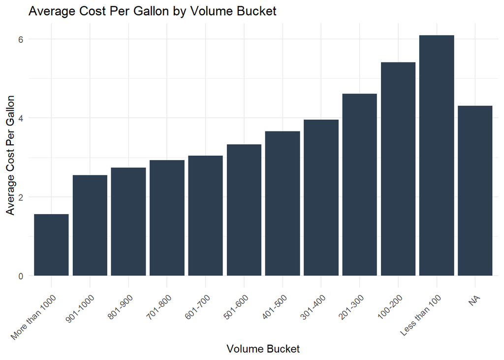

Based on the previous statement, we could look into any combination of customers that have an average cost per gallon of less than ~ $3.6. If we find more of those customer, we could possibly look into changing thresholds for ARTM by other characteristics than just annual volume.

```r
customer_totals_yearly %>%
  filter(total_gallons_ordered > 0) %>%
  group_by(volume_bucket, cold_drink_channel) %>%
  summarise(avg_cost_per_gallon = mean(avg_cost_per_gallon)) %>%
  filter(avg_cost_per_gallon < 3.6 & volume_bucket %in% c("Less than 100", "100-200", "201-300", "301-400") ) %>%
  arrange(desc(avg_cost_per_gallon))
```

```
## # A tibble: 5 × 3
## # Groups:   volume_bucket [2]
##   volume_bucket cold_drink_channel avg_cost_per_gallon
##   <chr>         <chr>                            <dbl>
## 1 301-400       EVENT                             3.59
## 2 301-400       WELLNESS                          3.41
## 3 301-400       PUBLIC SECTOR                     3.41
## 4 201-300       WORKPLACE                         3.23
## 5 301-400       WORKPLACE                         2.55
```

```r
customer_totals_yearly <- customer_totals_yearly %>%
  mutate(
    first_delivery_date = mdy(first_delivery_date),
    on_boarding_date = mdy(on_boarding_date),
    last_day_of_year = make_date(year, 12, 31),
    days_since_onboarding = as.integer(last_day_of_year - on_boarding_date),
    days_since_first_delivery = as.integer(last_day_of_year - first_delivery_date)
  )
```

# EDA

## Summary of cleanup steps taken so far

So far my main goal has been to create a dataset that has as much useful information as possible. It has also been aggregated to a yearly grain, since that’s what the business cares about volume-wise. Because of the nature of the granularity, most customers have two rows of data (for both years), but this could also be easily aggregated to on row of data by converting years and delivery numbers to “current year” and “previous year” - style.

When it comes to modeling on this dataset, it could be possible in many ways. For a project like this, a time series forecast might be ideal, however, since we only have two years of data, it might not be the best approach. This is why I think that using a more traditional predictive method with the chosen variables might be ideal.

## EDA on the clean dataset

Now that I have some good variables, I’m going to start seeing if there are any variables that could be used to predict whether somebody will reach the volume threshold (400 gallons) or not.

### Majority class

First, it’s a good idea just find out what the proportions of the target variable are.

```r
customer_totals_yearly %>%
  count(red_truck_flag) %>%
  mutate(proportion = n / sum(n))
```

```
## # A tibble: 2 × 3
##   red_truck_flag     n proportion
##            <dbl> <int>      <dbl>
## 1              0 39911      0.720
## 2              1 15557      0.280
```

### Customer relationship lenght and target variable

First, I’m curious to know if the days since onboarding has any effect:

```r
customer_totals_yearly %>%
  group_by(red_truck_flag, year) %>%
  summarize(avg_days_since_onboarding = mean(days_since_onboarding),
            avg_days_since_first_delivery = mean(days_since_first_delivery))
```

```
## # A tibble: 4 × 4
## # Groups:   red_truck_flag [2]
##   red_truck_flag  year avg_days_since_onboarding avg_days_since_first_delivery
##            <dbl> <dbl>                     <dbl>                         <dbl>
## 1              0  2023                     3000.                         1576.
## 2              0  2024                     2956.                         1709.
## 3              1  2023                     3915.                         1861.
## 4              1  2024                     3977.                         2054.
```

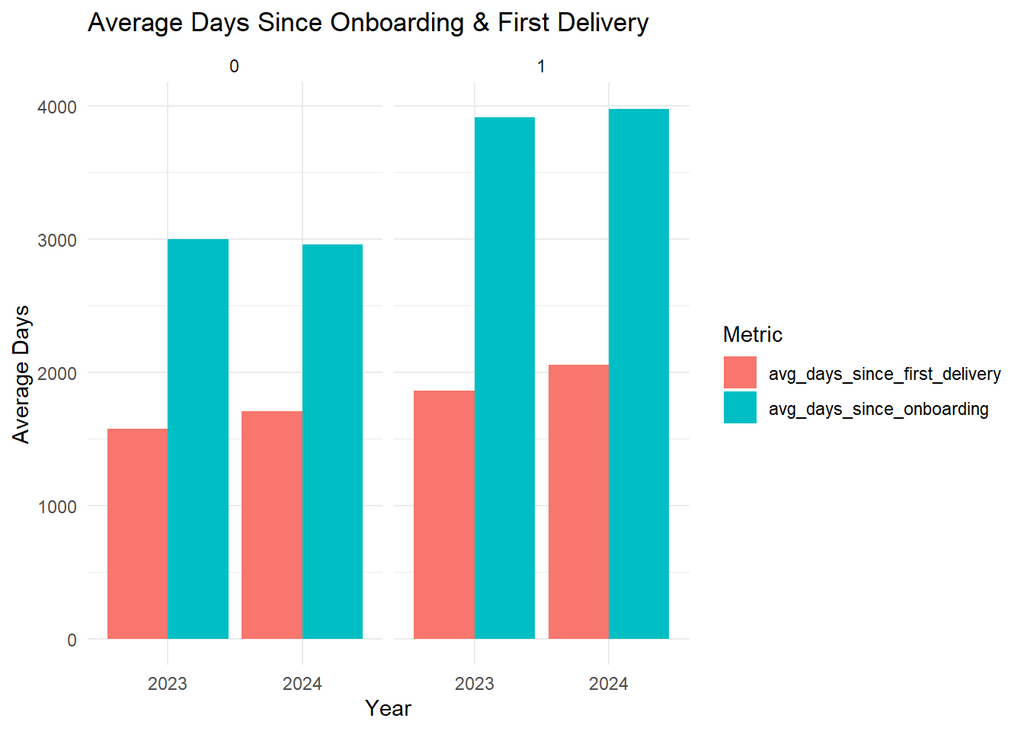

This is pretty interesting. We can see that customers who have been signed up for a longer time, have higher volumes. Those with over 400 gallons annually have close to 4000 days since signing up, and those with less than 400 gallons annually only average about 3000 days since signing up.

This could be useful information when trying to predict whether a customer will reach the threshold (high potential customer)

### Cold drink channel and the target variable

Next, let’s look at if customers using different channels have any relation to the target variable

```r
customer_totals_yearly %>%
  group_by(cold_drink_channel, red_truck_flag) %>%
  summarize(count = n(), .groups = "drop") %>%
  group_by(cold_drink_channel) %>%
  mutate(
    total_in_category = sum(count),  # Total observations in each cold_drink_channel
    percentage = (count / total_in_category) * 100
  ) %>%
  arrange(cold_drink_channel, red_truck_flag)
```

```
## # A tibble: 16 × 5
## # Groups:   cold_drink_channel [8]
##    cold_drink_channel red_truck_flag count total_in_category percentage
##    <chr>                       <dbl> <int>             <int>      <dbl>
##  1 ACCOMMODATION                   0  1659              2299       72.2
##  2 ACCOMMODATION                   1   640              2299       27.8
##  3 BULK TRADE                      0   731              2441       29.9
##  4 BULK TRADE                      1  1710              2441       70.1
##  5 DINING                          0 20200             27819       72.6
##  6 DINING                          1  7619             27819       27.4
##  7 EVENT                           0  3577              5525       64.7
##  8 EVENT                           1  1948              5525       35.3
##  9 GOODS                           0  9259             11101       83.4
## 10 GOODS                           1  1842             11101       16.6
## 11 PUBLIC SECTOR                   0  2235              3199       69.9
## 12 PUBLIC SECTOR                   1   964              3199       30.1
## 13 WELLNESS                        0   483               905       53.4
## 14 WELLNESS                        1   422               905       46.6
## 15 WORKPLACE                       0  1767              2179       81.1
## 16 WORKPLACE                       1   412              2179       18.9
```

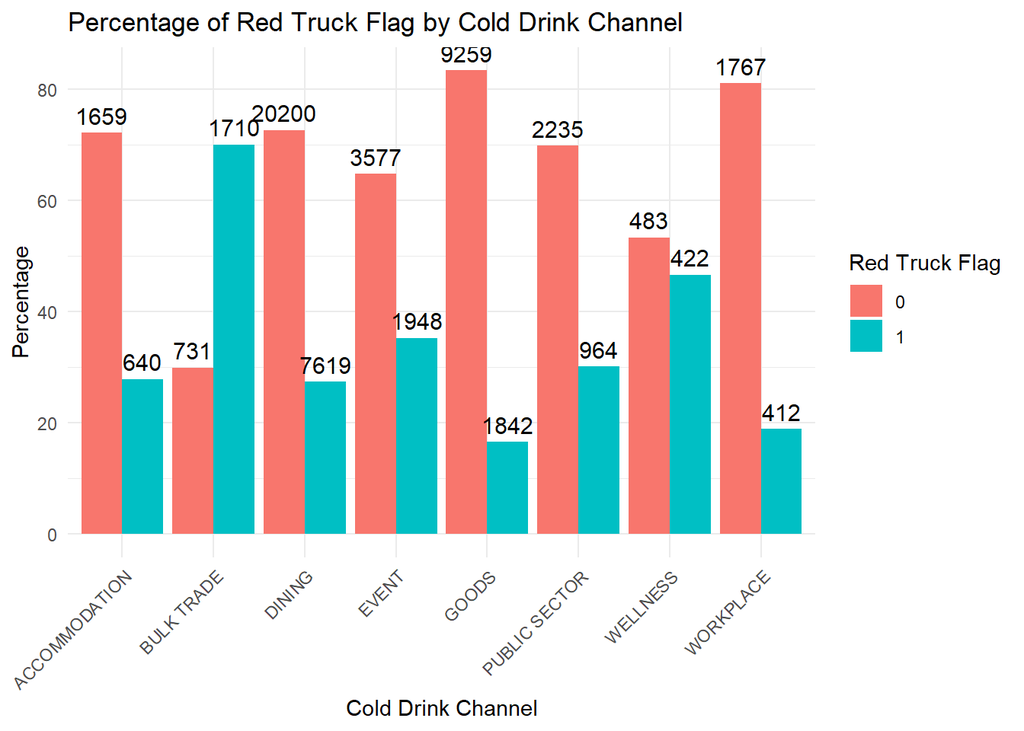

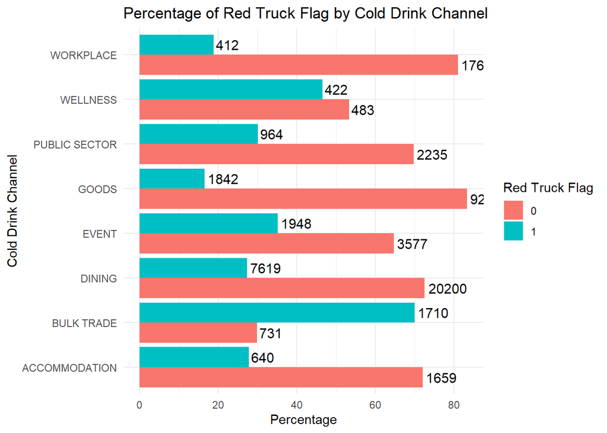

Again, interesting findings here. We can see that only for bulk trade cold drink channel the majority of customers have an annual order quantity of over 400 gallons. for others, the majority has an annual order quantity of less than 400 gallons.

### Location and Target variable

We were given information on the address. Well, it’s not really addresses but more like city information for ZIP codes. So, let’s see if those have anything to do with the target variable.

```r
customer_totals_yearly %>%
  group_by(state) %>%
  count(red_truck_flag) %>%
  mutate(proportion = round(n / sum(n),2))
```

```
## # A tibble: 10 × 4
## # Groups:   state [5]
##    state         red_truck_flag     n proportion
##    <chr>                  <dbl> <int>      <dbl>
##  1 Kansas                     0  9537       0.73
##  2 Kansas                     1  3598       0.27
##  3 Kentucky                   0  9184       0.72
##  4 Kentucky                   1  3577       0.28
##  5 Louisiana                  0   513       0.73
##  6 Louisiana                  1   193       0.27
##  7 Maryland                   0  6359       0.72
##  8 Maryland                   1  2532       0.28
##  9 Massachusetts              0 14318       0.72
## 10 Massachusetts              1  5657       0.28
```

Looks like the proportion for the states are along the same lines as the majority class classifier.

We could also look at states and cities but that probably wouldn’t be too significant statistically since there are much more cities and counties than states.

```r
customer_totals_yearly %>%
  group_by(county) %>% count(red_truck_flag) %>% mutate(proportion = round(n / sum(n),2))
```

```
## # A tibble: 265 × 4
## # Groups:   county [134]
##    county       red_truck_flag     n proportion
##    <chr>                 <dbl> <int>      <dbl>
##  1 Adair                     0   155       0.66
##  2 Adair                     1    81       0.34
##  3 Allegany                  0   372       0.71
##  4 Allegany                  1   149       0.29
##  5 Allen                     0    78       0.79
##  6 Allen                     1    21       0.21
##  7 Anderson                  0     3       1
##  8 Anne Arundel              0   822       0.73
##  9 Anne Arundel              1   301       0.27
## 10 Ballard                   0   164       0.67
## # ℹ 255 more rows
```

### Simplifying the dataset

Next, I’m going to try to simplify the dataset a little bit. Again, determining the gallon thresholds, Swire seems to care about the size of the orders, not the deliveries or loadings.

```r
customer_totals_simple <- customer_totals_yearly %>%
  select(customer_number, year, primary_group_number, frequent_order_type, cold_drink_channel, trade_channel,
         sub_trade_channel, local_market_partner, co2_customer, zip_code, city, state_short, county, total_orders,
         ordered_cases, ordered_gallons, total_gallons_ordered, avg_ordered_cases, avg_ordered_gallons, avg_total_gallons_ordered, ordered_cases_cost,
         ordered_gallons_cost, total_delivery_cost, avg_cost_per_order, avg_cost_per_gallon, red_truck_flag, volume_bucket, days_since_onboarding,
         days_since_first_delivery) %>%
  rename(avg_cases_per_order = avg_ordered_cases,
         avg_gallons_per_order= avg_ordered_gallons,
         avg_total_gallons_per_order = avg_total_gallons_ordered)

customer_totals_simple %>% head()
```

```
## # A tibble: 6 × 29
##   customer_number  year primary_group_number frequent_order_type
##             <dbl> <dbl>                <dbl> <chr>
## 1       501556470  2024                  376 MYCOKE LEGACY
## 2       501363456  2023                    1 SALES REP
## 3       501363456  2024                    1 SALES REP
## 4       600075150  2023                 2158 SALES REP
## 5       600075150  2024                 2158 SALES REP
## 6       500823056  2023                 2183 OTHER
## # ℹ 25 more variables: cold_drink_channel <chr>, trade_channel <chr>,
## #   sub_trade_channel <chr>, local_market_partner <lgl>, co2_customer <lgl>,
## #   zip_code <dbl>, city <chr>, state_short <chr>, county <chr>,
## #   total_orders <int>, ordered_cases <dbl>, ordered_gallons <dbl>,
## #   total_gallons_ordered <dbl>, avg_cases_per_order <dbl>,
## #   avg_gallons_per_order <dbl>, avg_total_gallons_per_order <dbl>,
## #   ordered_cases_cost <dbl>, ordered_gallons_cost <dbl>, …
```

```r
customer_totals_2023 <- customer_totals_simple %>% filter(year == 2023)
customer_totals_2024 <- customer_totals_simple %>% filter(year == 2024)

customer_totals_2023 <- customer_totals_2023 %>%
  select(customer_number, total_orders, ordered_cases, ordered_gallons, total_gallons_ordered, avg_cases_per_order, avg_gallons_per_order,
         avg_total_gallons_per_order, ordered_cases_cost, ordered_gallons_cost, total_delivery_cost, avg_cost_per_order, avg_cost_per_gallon,
         red_truck_flag, volume_bucket, days_since_onboarding, days_since_first_delivery) %>%
  rename_with(~ paste0(., "_previous"),
              -customer_number)

customer_totals_wide <- customer_totals_2024 %>%
  left_join(customer_totals_2023, by = "customer_number")

# checking that there's no more than one row per customer
customer_totals_wide %>% count(customer_number) %>% filter(n > 1)
```

```
## # A tibble: 0 × 2
## # ℹ 2 variables: customer_number <dbl>, n <int>
```

```r
customer_totals_wide <- customer_totals_wide %>%
  mutate(
    yoy_total_orders = round((total_orders - total_orders_previous) / total_orders_previous, 3),
    yoy_ordered_cases = round((ordered_cases - ordered_cases_previous) / ordered_cases_previous, 3),
    yoy_ordered_gallons = round((ordered_gallons - ordered_gallons_previous) / ordered_gallons_previous, 3),
    yoy_total_gallons_ordered = round((total_gallons_ordered - total_gallons_ordered_previous) / total_gallons_ordered_previous, 3)
  )
```

Steps taken here:

What I did here was I created a dataset that has one row per customer, with their volume statistics for the current year, and their volume statistics for the previous year. I also created columns to display the change from previous year to this year. This could be used for using previous years metrics to predict the current years (trained on this) to find out of this is something we can use to predict whether a customer has the potential to become a red truck customer or not.